# Final Project

STAT 230 Spring 2025

Author

Keziah White

# Data and Questions

This data set from https://catalog.data.gov/dataset/popular-baby-namesshows provides information on baby names in the United States, including the name, gender, year of birth, and the number of occurrences for each name. It allows analysis of naming trends and the popularity of specific names over time, across different genders, and by state.

Some questions we can answer with this data:

1.For each baby name, how has its popularity varied across all years, genders, and ethnicities?”

2.Is there a significant difference in the average number of babies given a particular name across different ethnicities?

```r
library(tidyverse)
library(effects)
Baby_Names <- read_csv("~/STAT230/STAT230/Popular_Baby_Names.csv")
```

#Histogram

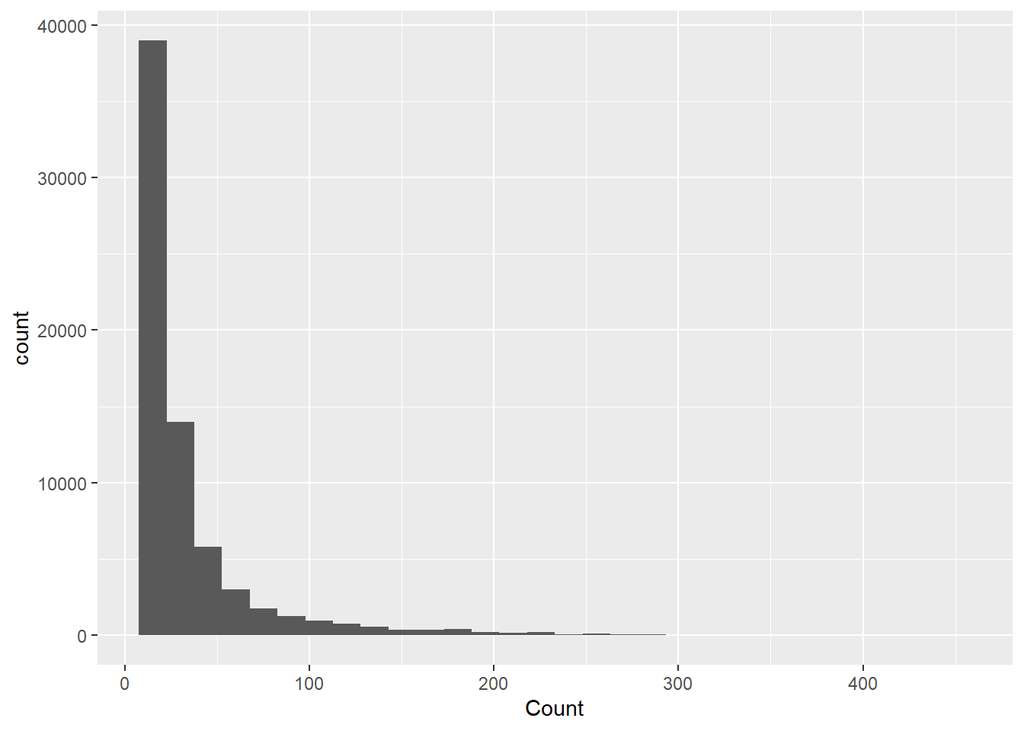

```r
Baby_Names |>
  ggplot(aes(x = `Count`)) +
  geom_histogram()
```

#Boxplot

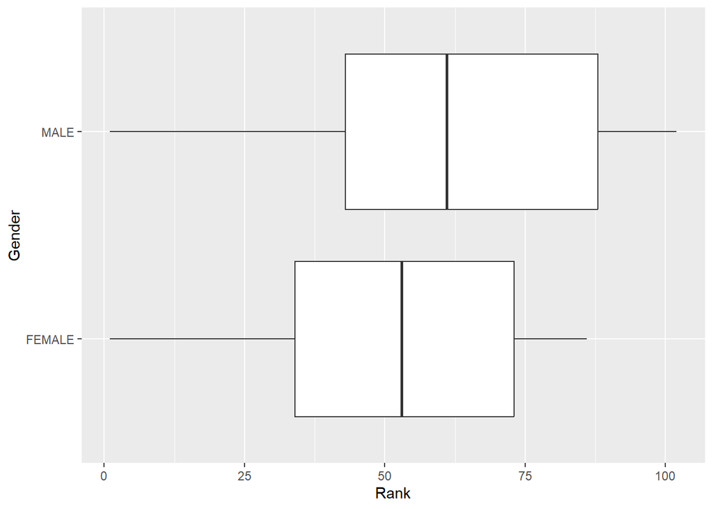

```r
Baby_Names |>
  ggplot(aes(x = `Rank`, y = `Gender`)) +
  geom_boxplot()
```

#Mean,Standard Deviation, Mnimum and Maximum

```r
Baby_Names |>
  group_by(`Child's First Name`) |>
  summarize(mean = mean(Count, na.rm = TRUE),
            min = min(Count, na.rm = TRUE),
            max = max(Count, na.rm = TRUE),
            sd = sd(Count, na.rm = TRUE)) |>
  mutate(range = max - min)
```

```
# A tibble: 3,302 × 6
   `Child's First Name`  mean   min   max     sd range
   <chr>                <dbl> <dbl> <dbl>  <dbl> <dbl>
 1 AALIYAH               63.8    55    69  5.64     14
 2 AARAV                 12.5    10    15  2.59      5
 3 AARON                 77.0    51   126 25.3      75
 4 AAYAN                 13      13    13  0         0
 5 ABBY                  10.5    10    11  0.519     1
 6 ABDIEL                11.5    11    12  0.519     1
 7 ABDOUL                13      10    16  3.11      6
 8 ABDOULAYE             14      13    15  1.04      2
 9 ABDUL                 17      15    20  2.21      5
10 ABDULLAH              29      28    30  1.04      2
# ℹ 3,292 more rows
```

#Sample t-test

```r
Two_Names <- Baby_Names |>
  filter(`Child's First Name` %in% c("SOPHIA", "Victor"))
t.test(Count ~ `Child's First Name`, data = Two_Names)
```

```
    Welch Two Sample t-test

data:  Count by Child's First Name
t = 10.582, df = 56.334, p-value = 5.249e-15
alternative hypothesis: true difference in means between group SOPHIA and group Victor is not equal to 0
95 percent confidence interval:
  91.91699 134.83650
sample estimates:
mean in group SOPHIA mean in group Victor
           141.42593             28.04918
```

#ANOVA

```r
name_data <-Baby_Names |>
  filter(`Child's First Name` == "Michael")

anova <- aov(Count ~ Ethnicity, data = name_data)
summary(anova)
```

```
            Df Sum Sq Mean Sq F value Pr(>F)
Ethnicity    3 510125  170042   258.2 <2e-16 ***
Residuals   76  50057     659
---
Signif. codes:  0 '***' 0.001 '**' 0.01 '*' 0.05 '.' 0.1 ' ' 1
```

CONCLUSION: For this project, I looked at trends in baby name popularity using a dataset from Data.gov. I started by making a histogram to see how often different names were used, and it showed that most names aren’t super common, but a few are really popular. I also made a boxplot to compare the ranks of names by gender, which gave a nice visual of how boys’ and girls’ names are ranked differently. Then I calculated some basic stats — the mean, minimum, maximum, standard deviation, and range — for each name to see how much their popularity changed over time.

After that, I ran a t-test comparing the number of babies named “SOPHIA” versus “Victor” to see if there was a real difference between how popular those names were. I also did an ANOVA test to check if the name “Michael” was used differently across different ethnic groups. These tests helped me figure out if popularity differences were actually meaningful or just random. Overall, this analysis gave me a better understanding of naming trends and how names can vary depending on things like gender and ethnicity.